# BCB420 A2: Differencial Gene expression and Preliminary ORA

Tianyan Zhou

# Introduction

In this notebook, I am going to perform differencial gene expression analysis and over-threshold representation analysis to the normalized data of GSE150621, which studys the gestational diabetes(GDM) and human amniocytes. In the original paper [Exposure to gestational diabetes enriches immune-related pathways in the transcriptome and methylome of human amniocytes](https://doi.org/10.1210/clinem/dgaa466)(Pinney et al. 2020), a nested case-control study was performed in second trimeseter amniocytes matched for offspring sex, maternal race/ethnicity, maternal age, gestational age at amniocentesis, gestational age at birth and gestational diabetes status. Sex-specific RNA-sequencing was completed and gene expression changes were identified. Therefore, the samples are grouped by GDM-exposured and control, and by sex. There are 14 of them, with the last two letters indicated their groups: C for controls, D for GDM exposured, F for female, and M for male.

# Preparations and Data Review

## Check for the packages required for this assignments

```r
# check package is installed
if (!requireNamespace("ComplexHeatmap", quietly = TRUE))
  BiocManager::install("ComplexHeatmap")
if (!requireNamespace("circlize", quietly = TRUE))
  install.packages("circlize")
if (!requireNamespace("gprofiler2", quietly = TRUE))
  install.packages("gprofiler2")
if (!requireNamespace("BiocManager", quietly = TRUE)) {
  install.packages("BiocManager")
}
if (!requireNamespace("ggplot2", quietly = TRUE)) {
  install.packages("ggplot2")
}
if (!requireNamespace("tibble", quietly = TRUE)) {
  install.packages("tibble")
}
if (!requireNamespace("dplyr", quietly = TRUE)) {
  install.packages("dplyr")
}
if (!requireNamespace("edgeR", quietly = TRUE)) {
  install.packages("edgeR")
}
if (!requireNamespace("limma", quietly = TRUE)) {
  install.packages("limma")
}
if(!requireNamespace("tidyr", quietly = TRUE)) {
  install.packages("tidyr")
}
if(!requireNamespace("stringr", quietly = TRUE)) {
  install.packages("stringr")
}
if(!requireNamespace("knitr", quietly = TRUE)) {
  install.packages("knitr")
}
```

## Attach the packages in library.

```r
suppressPackageStartupMessages({
library("edgeR")
library("circlize")
library("ComplexHeatmap")
library("gprofiler2")
library("ggplot2")
library("tibble")
library("dplyr")
library("stringr")
library("knitr")
})
```

## Load the data from A1 and set the groups

```r
# Read the normalized counts of GSE150621 into a table
data<-read.table("./GSE150621_finalized_normalized_counts.txt")
head(data)
```

|  | HGNC_genes | refGene | Sample_279_CF | Sample_571_CF | Sample_665_CF | Sample_812_CF | Sample_223_CM | Sample_487_CM | Sample_511_CM | Sample_620_CM | Sample_324_DF | Sample_338_DF | Sample_566_DF | Sample_252_DM | Sample_323_DM | Sample_763_DM |
| --- | --- | --- | --- | --- | --- | --- | --- | --- | --- | --- | --- | --- | --- | --- | --- | --- |
| 1 | SGIP1 | SGIP1 | 42.7118099 | 58.253851 | 31.7471880 | 77.593467 | 38.3046789 | 67.277416 | 65.195821 | 40.6669103 | 24.692620 | 63.0953449 | 46.898301 | 50.6381269 | 36.2972257 | 47.604698 |
| 2 | NECAP2 | NECAP2 | 56.4272467 | 64.657528 | 89.7450707 | 57.887190 | 78.1328394 | 66.234153 | 76.175602 | 81.0364556 | 61.760628 | 81.4987343 | 78.951097 | 66.0014205 | 83.3546327 | 74.000372 |
| 3 | AZIN2 | AZIN2 | 1.7594550 | 5.145811 | 1.9522429 | 3.405129 | 1.4094795 | 4.707724 | 3.216663 | 2.5681519 | 1.651602 | 2.8977328 | 4.826256 | 4.0297164 | 2.0479420 | 3.824373 |
| 5 | CLIC4 | CLIC4 | 404.3698692 | 510.235781 | 592.3430315 | 577.162087 | 825.1155340 | 537.606413 | 500.918825 | 674.2795396 | 524.395419 | 493.7848098 | 538.985729 | 414.1718770 | 628.6616127 | 612.662091 |
| 6 | SLC45A1 | SLC45A1 | 0.8173846 | 4.868101 | 0.6856091 | 4.042685 | 0.7669227 | 2.138689 | 1.186032 | 0.9641833 | 1.372458 | 0.6687076 | 1.951040 | 0.9037232 | 0.6901904 | 1.737215 |
| 7 | TGFBR3 | TGFBR3 | 8.3400939 | 10.177271 | 6.9258141 | 4.723711 | 4.6222637 | 4.251296 | 7.619357 | 3.5323352 | 9.002397 | 6.8263897 | 6.219856 | 10.0150304 | 13.7246056 | 11.385634 |

```r
# The "samples" data frame is created by applying a function to each of the column names. The function splits the column names by "_" and returns the third element of the resulting vector. This third element is assumed to be a label that identifies the sample.
samples <- data.frame(
  lapply(colnames(data)[3:16],
         FUN=function(x){
           unlist(strsplit(x, split = "_"))[3]}))

# The resulting "samples" data frame is transposed using the "t" function, so that the labels become row names.
samples=as.data.frame(t(samples))

# Samples with a label containing "C" is assigned to the control group, D" is assigned to the case group of DPM exporsure, "F" is assigned to the female group, and "M" is assigned to the male group.
samples[which(samples[,1]=="CF"|samples[,1]=="CM"),2]="Control"
samples[which(samples[,1]=="DF"|samples[,1]=="DM"),2]="Case"
samples[which(samples[,1]=="CF"|samples[,1]=="DF"),3]="Female"
samples[which(samples[,1]=="CM"|samples[,1]=="DM"),3]="Male"
colnames(samples)=c("label","Group","Gender")
row.names(samples)=colnames(data)[3:16]
```

### A multidimensional scaling (MDS) plot based on the “data” data frame.

[figure not shown]

```r
# MDS plot from A1 that shows the similarity between the samples based on their gene expression profiles. Samples that are more similar are closer together in the plot.

# Extracted from columns 3 to the last column of the "data" data frame and assigned to a new variable called "heatmap_matrix".
heatmap_matrix <- data[,3:ncol(data)]

# The row names of the "heatmap_matrix" are set to the values of the "refGene" column of the "data" data frame.
rownames(heatmap_matrix) <- data$refGene


# The "plotMDS" function is called on the "heatmap_matrix" with the color argument set to a vector of 8 reds and 6 blues, corresponding to the case/control groups of 14 columns in the "heatmap_matrix".
plotMDS(heatmap_matrix,col=c(rep("red",8),rep("blue",6)))

# The "legend" function is used to add a legend to the plot. The legend is positioned at the coordinates (2000, -1200) and shows the labels "Case" and "Control" with the corresponding red and blue colors used in the MDS plot. The "cex" parameter controls the size of the legend text.
legend(x=2000,y=-1200,legend=c("Case","Control"),
fill=c("red","blue"),cex = 0.7)
```

# Differencial Expression

## Simple Model based on samples’ group of case and control

```r
# Simple model: sets up a linear model to analyze the gene expression data based on the sample group information in the "samples" data frame.

# The "model.matrix" function is called on the "samples" data frame with the formula "~ samples$Group" to create a matrix that defines the linear model. The resulting matrix is assigned to the "model_design" variable.
model_design <- model.matrix(~ samples$Group )

# Display the first 14 rows of the "model_design" matrix in an HTML table format.
kable(model_design[1:14,], type="html")
```

| (Intercept) | samples$GroupControl |
| --- | --- |
| 1 | 1 |
| 1 | 1 |
| 1 | 1 |
| 1 | 1 |
| 1 | 1 |
| 1 | 1 |
| 1 | 1 |
| 1 | 1 |
| 1 | 0 |
| 1 | 0 |
| 1 | 0 |
| 1 | 0 |
| 1 | 0 |
| 1 | 0 |

```r
# The expression data is extracted from columns 3 to 16 of the "data" data frame and assigned to a variable called "expressionMatrix". The row names of the "expressionMatrix" are set to the values of the "refGene" column of the "data" data frame, and the column names are set to the sample labels extracted from the column names of the "data" data frame
expressionMatrix <- as.matrix(data[,3:16])
rownames(expressionMatrix) <-data$refGene
colnames(expressionMatrix) <-colnames(data)[3:16]

# An "ExpressionSet" object called "minimalSet" is created from the "expressionMatrix" using the "assayData" argument.
minimalSet <- Biobase::ExpressionSet(assayData=expressionMatrix)

#  "lmFit" function is called on the "minimalSet" and the "model_design" matrix to fit a linear model to the gene expression data. The resulting fit is assigned to the "fit" variable.
fit <- limma::lmFit(minimalSet, model_design)

# The "eBayes" function is called on the "fit" variable to compute moderated t-statistics and log-odds of differential expression for each gene. The resulting fit is assigned to the "fit2" variable.
fit2 <- limma::eBayes(fit, trend=TRUE)

# The "topTable" function is called on the "fit2" variable to generate a table of the top genes ranked by their moderated t-statistics.
topfit <- limma::topTable(fit2,
                   coef=ncol(model_design),
                   adjust.method = "BH",
                   number = nrow(expressionMatrix))

# The resulting "topfit" table is combined with the "refGene" column to create a new data frame called "output_hits". The first column of "output_hits" is renamed to "refgene". The resulting data frame is sorted by ascending p-value using the "order" function.
output_hits <- cbind(rownames(topfit),topfit)
colnames(output_hits)[1]="refgene"
output_hits <- output_hits[order(output_hits$P.Value),]

# Display the first 10 rows of the "output_hits" data frame in an HTML table format,
kable(output_hits[1:10,],type="html",row.names = FALSE)
```

| refgene | logFC | AveExpr | t | P.Value | adj.P.Val | B |
| --- | --- | --- | --- | --- | --- | --- |
| DGKG | -1.824802 | 1.694469 | -6.864903 | 0.0000085 | 0.1220814 | -4.185206 |
| SP100 | -40.905043 | 103.296613 | -5.126070 | 0.0001631 | 0.6967953 | -4.255340 |
| MME | -26.352951 | 33.899722 | -4.997529 | 0.0002062 | 0.6967953 | -4.262185 |
| IFI35 | -6.555927 | 7.659592 | -4.948718 | 0.0002255 | 0.6967953 | -4.264856 |
| IFI44 | -20.502379 | 14.906365 | -4.907980 | 0.0002431 | 0.6967953 | -4.267117 |
| IFI6 | -43.499044 | 26.431933 | -4.750623 | 0.0003255 | 0.7536419 | -4.276118 |
| LINC00942 | -2.310736 | 1.898913 | -4.684747 | 0.0003681 | 0.7536419 | -4.280017 |
| RPLP0P2 | -4.383426 | 5.024882 | -4.462672 | 0.0005595 | 0.8947206 | -4.293747 |
| LPXN | -3.857799 | 6.929437 | -4.460415 | 0.0005619 | 0.8947206 | -4.293892 |
| TRIM22 | -53.445917 | 102.702274 | -4.310158 | 0.0007483 | 1.0000000 | -4.303717 |

```r
# Two lines are printed to display the number of genes that pass the threshold of p-value < 0.05 and the adjusted p-value < 0.05 in the "Simple Model". I use cutoff 0.05 becuase p value <0.05 is statistically significant and it is a commonly used statistic threshold.
print(c("The number gene pass the threshold p-value <0.05 in Simple Model:",length(which(output_hits$P.Value < 0.05))))
```

```
## [1] "The number gene pass the threshold p-value <0.05 in Simple Model:"
## [2] "360"
```

```r
print(c("The number gene pass the adjust p-value <0.05 in Simple Model:",length(which(output_hits$adj.P.Val < 0.05))))
```

```
## [1] "The number gene pass the adjust p-value <0.05 in Simple Model:"
## [2] "0"
```

## Multiple Hypothesis Testing

### Account for the gender variability

I used Benjamin-Hochberg (Benjamini and Hochberg 1995) method to correct every gene. The reason is that, BH is a powerful and common tool that decreased the false discovery rate.

```r
# A new linear model is created with the addition of the Gender variable to the previous Group variable in the model matrix with the same parameters.
# The addition of the Gender variable to the model matrix can help to adjust for the confounding effect of gender on gene expression.
model_design_gender <- model.matrix(~samples$Gender+samples$Group)

kable(model_design_gender[1:5,],type="html")
```

[output not shown]

```r
fit_gender <- limma::lmFit(minimalSet, model_design_gender)

fit2_gender <- limma::eBayes(fit_gender,trend=TRUE)

topfit_gender <- limma::topTable(fit2_gender,
                       coef=ncol(model_design_gender),
                       adjust.method = "BH",
                       number = nrow(expressionMatrix))

output_hits_gender <- cbind(rownames(topfit_gender),topfit_gender)

colnames(output_hits_gender)[1]="refgene"

# Sort by p value and display the top 10
output_hits_gender <- output_hits_gender[order(output_hits_gender$P.Value),]

kable(output_hits_gender[1:10,],type="html",row.names = FALSE)
```

| refgene | logFC | AveExpr | t | P.Value | adj.P.Val | B |
| --- | --- | --- | --- | --- | --- | --- |
| DGKG | -1.824802 | 1.694469 | -6.615938 | 0.0000185 | 0.2653294 | -4.516694 |
| SP100 | -40.905043 | 103.296613 | -4.975977 | 0.0002695 | 1.0000000 | -4.529535 |
| IFI35 | -6.555927 | 7.659592 | -4.818120 | 0.0003556 | 1.0000000 | -4.531175 |
| MME | -26.352951 | 33.899722 | -4.810214 | 0.0003606 | 1.0000000 | -4.531259 |
| IFI44 | -20.502379 | 14.906365 | -4.771848 | 0.0003859 | 1.0000000 | -4.531672 |
| RPLP0P2 | -4.383426 | 5.024882 | -4.687429 | 0.0004485 | 1.0000000 | -4.532598 |
| IFI6 | -43.499044 | 26.431933 | -4.578272 | 0.0005453 | 1.0000000 | -4.533834 |
| LINC00942 | -2.310736 | 1.898913 | -4.510586 | 0.0006160 | 1.0000000 | -4.534623 |
| MAP1A | -118.867804 | 198.087722 | -4.331676 | 0.0008525 | 1.0000000 | -4.536791 |
| LPXN | -3.857799 | 6.929437 | -4.296417 | 0.0009093 | 1.0000000 | -4.537234 |

```r
print(c("The number gene pass the threshold p-value <0.05 in Gender Model:",length(which(output_hits_gender$P.Value < 0.05))))
```

```
## [1] "The number gene pass the threshold p-value <0.05 in Gender Model:"
## [2] "358"
```

```r
print(c("The number gene pass the adjust p-value <0.05 in Gender Model:",length(which(output_hits_gender$adj.P.Val < 0.05))))
```

```
## [1] "The number gene pass the adjust p-value <0.05 in Gender Model:"
## [2] "0"
```

### Heatmap

From this result, it is clear that samples with GDM-exposred samples clustered together with mostly red top-hits, and the control samples clustered together with mostly blue top-hits.

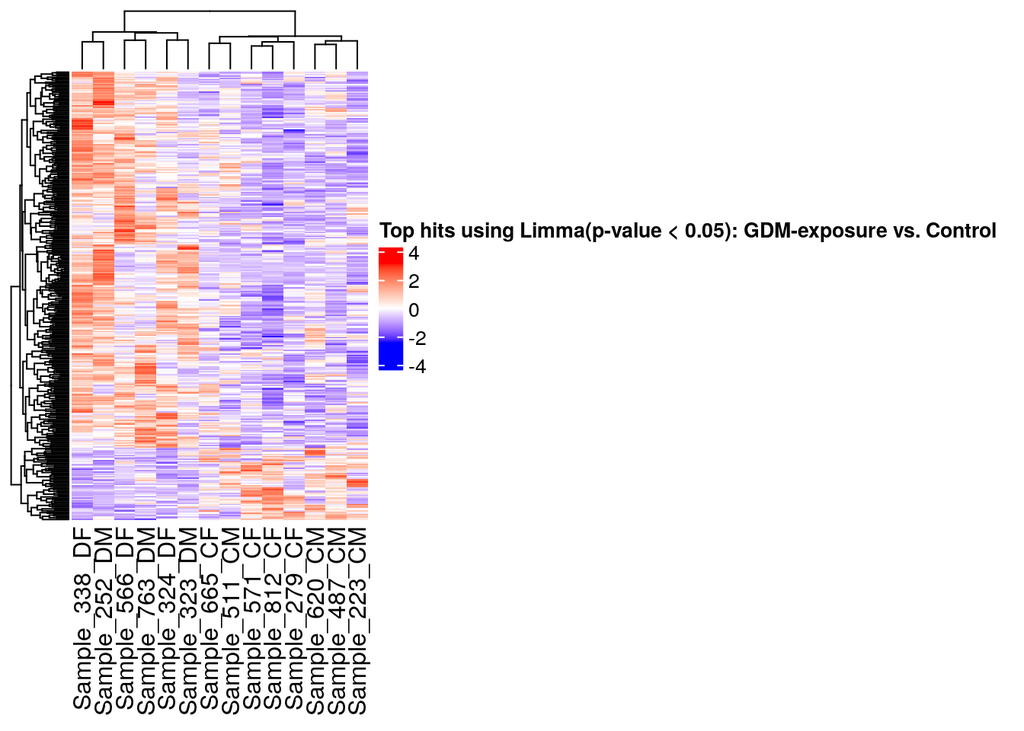

```r
top_hits <- output_hits_gender$refgene[
output_hits_gender$P.Value<0.05]

heatmap_matrix_tophits <- t(
scale(t(heatmap_matrix[
which(rownames(heatmap_matrix) %in% top_hits),])))

if(min(heatmap_matrix_tophits) == 0){
heatmap_col = circlize::colorRamp2(c( 0, max(heatmap_matrix_tophits)),
c( "white", "red"))
} else {
heatmap_col = colorRamp2(c(min(heatmap_matrix_tophits), 0,
max(heatmap_matrix_tophits)), c("blue", "white", "red"))
}

current_heatmap <- ComplexHeatmap::Heatmap(as.matrix(heatmap_matrix_tophits),
cluster_rows = TRUE,
cluster_columns = TRUE,
show_row_dend = TRUE,
show_column_dend = TRUE,
col=heatmap_col,
show_column_names = TRUE,
show_row_names = FALSE,
show_heatmap_legend = TRUE,
name = "Top hits using Limma(p-value < 0.05): GDM-exposure vs. Control"
)

plot(current_heatmap)
```

## Comparision: Simpe vs. Gender Limma

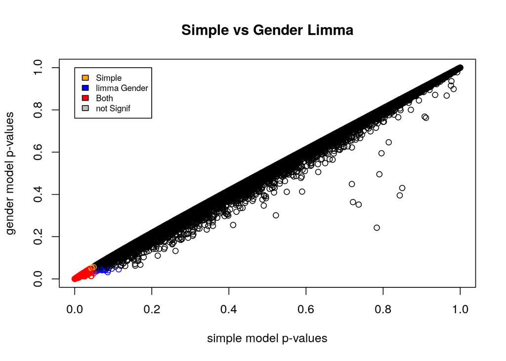

```r
# The analysis is based on gene expression data, with the aim of identifying genes that are differentially expressed between two groups (case vs control) and exploring whether adding gender as a covariate to the model improves the results.

# Creates the design matrix for the simple model using only the information on the group (samples$Group) as a predictor.
simple_model_pvalues <- data.frame(refgene =output_hits$refgene,
                                   simple_pvalue=output_hits$P.Value)

# Repeats the same procedure, but adds the gender (samples$Gender) as an additional predictor.
gender_model_pvalues <- data.frame(refgene =
                                  output_hits_gender$refgene,
                                gender_pvalue = output_hits_gender$P.Value)

# Models is then compared using a scatter plot, where the x-axis represents the p-values from the simple model and the y-axis represents the p-values from the gender model. The color of each point represents whether the gene is significant in the simple model (orange), gender model (blue), both models (red), or neither model (grey).
two_models_pvalues <- merge(simple_model_pvalues,
                            gender_model_pvalues,by.x=1,by.y=1)
two_models_pvalues$colour <- "black"
two_models_pvalues$colour[
  two_models_pvalues$simple_pvalue<0.05] <- "orange"
two_models_pvalues$colour[
  two_models_pvalues$gender_pvalue<0.05] <- "blue"
two_models_pvalues$colour[
  two_models_pvalues$simple_pvalue<0.05 &
    two_models_pvalues$gender_pvalue<0.05] <- "red"
plot(two_models_pvalues$simple_pvalue,
     two_models_pvalues$gender_pvalue,
     col = two_models_pvalues$colour,
     xlab = "simple model p-values",
     ylab ="gender model p-values",
     main="Simple vs Gender Limma")
legend(0,1,legend=c("Simple","limma Gender","Both","not Signif"),
fill=c("orange","blue","red","grey"),cex = 0.7)
```

## Using the quasi-likelihood F-test (QLF) by EdgeR

There are 401 genes pass the p < 0.05 threshold and 0 of them pass FDR < 0.05

```r
# create a DGEList object d from the count data and grouping information using the DGEList() function.
d = DGEList(counts=expressionMatrix, group=samples$Group)

# I estimate the dispersion using the estimateDisp() function with the model_design_gender model matrix.
d <- estimateDisp(d, model_design_gender)

# Fit a generalized linear model using the glmQLFit() function with the model_design_gender model matrix.
fit <- glmQLFit(d, model_design_gender)

# Use the glmQLFTest() function to perform a contrast of interest between the control and treatment groups
qlf.pos_vs_neg <- glmQLFTest(fit,coef = "samples$GroupControl")
kable(topTags(qlf.pos_vs_neg), type="html",row.names = FALSE)
```

| logFC | logCPM | F | PValue | FDR |
| --- | --- | --- | --- | --- |
| -2.8334044 | 4.854485 | 43.99107 | 0.0000071 | 0.0853025 |
| -2.2059407 | 4.103374 | 40.18761 | 0.0000119 | 0.0853025 |
| -1.2407730 | 5.161937 | 32.67551 | 0.0000373 | 0.1649817 |
| -1.5724349 | 4.958207 | 30.19268 | 0.0000567 | 0.1649817 |
| -2.4987900 | 4.493680 | 30.10356 | 0.0000576 | 0.1649817 |
| -3.1050278 | 5.564898 | 28.96479 | 0.0000703 | 0.1679848 |
| -3.0608567 | 2.455475 | 25.24204 | 0.0001409 | 0.2663249 |
| -1.3097728 | 3.279000 | 24.35787 | 0.0001678 | 0.2663249 |
| -0.8614091 | 6.710179 | 24.25471 | 0.0001713 | 0.2663249 |
| -1.1673469 | 5.915746 | 23.84979 | 0.0001859 | 0.2663249 |

| x |
| --- |
| BH |

| x |
| --- |
| samples$GroupControl |

| x |
| --- |
| glm |

```r
# Use the topTags() function to extract the top differentially expressed genes based on their P Value and FDR values.
qlf_output_hits <- topTags(qlf.pos_vs_neg,sort.by = "PValue",
                           adjust.method = "BH",
                           n = nrow(data))

# Print out the number of genes passing a threshold of P Value < 0.05 and FDR < 0.05
print(c("The number gene pass the threshold p-value <0.05 in qlf Model:",length(which(qlf_output_hits$table$PValue < 0.05))))
```

```
## [1] "The number gene pass the threshold p-value <0.05 in qlf Model:"
## [2] "401"
```

```r
print(c("The number gene pass the Adjust p-value <0.05 in qlf Model:",length(which(qlf_output_hits$table$FDR < 0.05))))
```

```
## [1] "The number gene pass the Adjust p-value <0.05 in qlf Model:"
## [2] "0"
```

### Heatmap

From this result, it is clear that samples with GDM-exposured samples clustered together with mostly red top-hits, and the control samples clustered together with mostly blue top-hits.

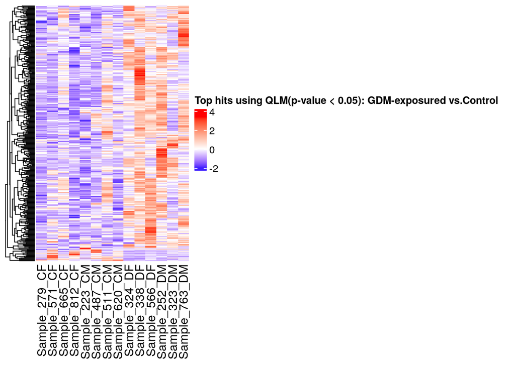

```r
top_hits <- rownames(qlf_output_hits$table)[
output_hits_gender$P.Value<0.05]

heatmap_matrix_tophits <- t(
scale(t(heatmap_matrix[which(rownames(heatmap_matrix)
%in% top_hits),])))

if(min(heatmap_matrix_tophits) == 0){
heatmap_col = colorRamp2(c( 0, max(heatmap_matrix_tophits)),
c( "white", "red"))
} else {
heatmap_col = colorRamp2(c(min(heatmap_matrix_tophits), 0,
max(heatmap_matrix_tophits)),
c("blue", "white", "red"))
}
current_heatmap <- Heatmap(as.matrix(heatmap_matrix_tophits),
cluster_rows = TRUE,
cluster_columns = FALSE,
show_row_dend = TRUE,
show_column_dend = FALSE,
col=heatmap_col,
show_column_names = TRUE,
show_row_names = FALSE,
show_heatmap_legend = TRUE,
name = "Top hits using QLM(p-value < 0.05): GDM-exposured vs.Control "
)

current_heatmap
```

# Threshold over-Representation Analysis

## Display the top-hits with threshold < 0.05 generated by using the BH method of edge R aboved

```r
kable(topTags(qlf.pos_vs_neg), type="html")
```

|  | logFC | logCPM | F | PValue | FDR |
| --- | --- | --- | --- | --- | --- |
| IFI6 | -2.8334044 | 4.854485 | 43.99107 | 0.0000071 | 0.0853025 |
| IFI44 | -2.2059407 | 4.103374 | 40.18761 | 0.0000119 | 0.0853025 |
| MME | -1.2407730 | 5.161937 | 32.67551 | 0.0000373 | 0.1649817 |
| IFIT3 | -1.5724349 | 4.958207 | 30.19268 | 0.0000567 | 0.1649817 |
| IFI44L | -2.4987900 | 4.493680 | 30.10356 | 0.0000576 | 0.1649817 |
| MX1 | -3.1050278 | 5.564898 | 28.96479 | 0.0000703 | 0.1679848 |
| ESM1 | -3.0608567 | 2.455475 | 25.24204 | 0.0001409 | 0.2663249 |
| IFI35 | -1.3097728 | 3.279000 | 24.35787 | 0.0001678 | 0.2663249 |
| TRIM22 | -0.8614091 | 6.710179 | 24.25471 | 0.0001713 | 0.2663249 |
| DDX60L | -1.1673469 | 5.915746 | 23.84979 | 0.0001859 | 0.2663249 |

| x |
| --- |
| BH |

| x |
| --- |
| samples$GroupControl |

| x |
| --- |
| glm |

## 20 up-regulated genes

```r
length(which(qlf_output_hits$table$PValue < 0.05
& qlf_output_hits$table$logFC > 0))
```

```
## [1] 20
```

## 381 down-regulated genes

```r
length(which(qlf_output_hits$table$PValue < 0.05
& qlf_output_hits$table$logFC < 0))
```

```
## [1] 381
```

## Created a Threshold lists of genes

```r
upreg_genes<- row.names(qlf_output_hits)[
  which(qlf_output_hits$table$PValue < 0.05 & qlf_output_hits$table$logFC > 0)]

downreg_genes <- row.names(qlf_output_hits)[
  which(qlf_output_hits$table$PValue < 0.05 & qlf_output_hits$table$logFC < 0)]
```

```r
write.table(x=upreg_genes,
            "upregulated_genes.txt",sep='\t',
            row.names = FALSE,col.names = FALSE,quote = FALSE)
write.table(x=downreg_genes,
            "downregulated_genes.txt",sep='\t',
            row.names = FALSE,col.names = FALSE,quote = FALSE)
```

## G:Profiler analysis on the thresholded gene lists

I used annotation data from GO biological process, reactome, and wikipathways. Their versions are December 4, 2022, December 28, 2022, and Decmber 10, 2022 respectively. Because GO BP involves in the the description of biological process, reactome is very detailed, wikipathways because more annotation databases are included for a higher coverage.

### results using both the upregulated and downregulated genes:

The top-hit for GO:BP term is negative regulation of viral process, inteerferon alpha/beta signalling for reactome, and type I interferon induction and signaling during SARS-CoV-2 infection.

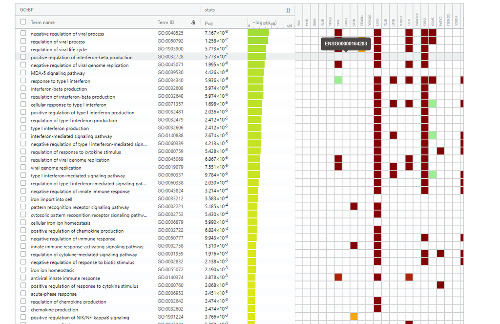

*Figure 1. All differencially expressed genes over-representation analysis results from GO:BP, term size = 200.*

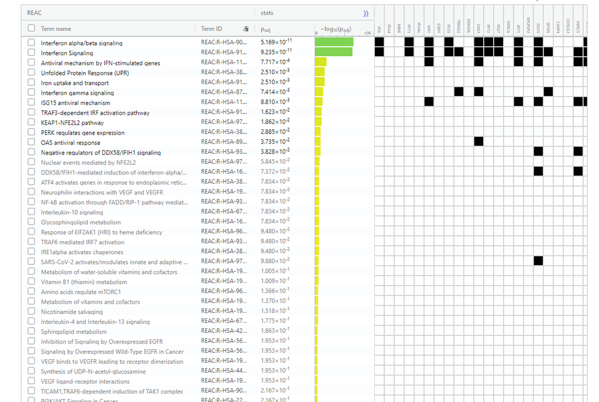

*Figure 2. All differencially expressed genes over-representation analysis results from Reactome, term size = 200.*

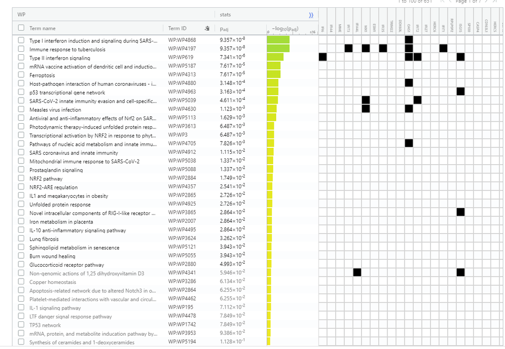

*Figure 3. All differencially expressed genes over-representation analysis results from WikiPathways, term size = 200.*

### results only using the upregulated genes:

The top-hit term for GO:BP is positive regulation of BMP signalling pathway, Loss of Function of FBXW7 in Cancer and NOTCH1 Signaling for reactome, and Clock-controlled autophagy in bone metabolism for wikiPathways.

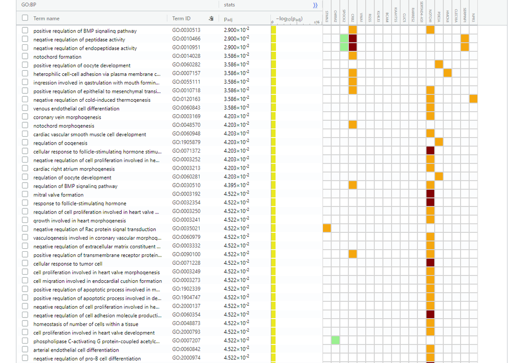

*Figure 4. Up-regulated genes over-representation analysis results from GO:BP, term size = 200.*

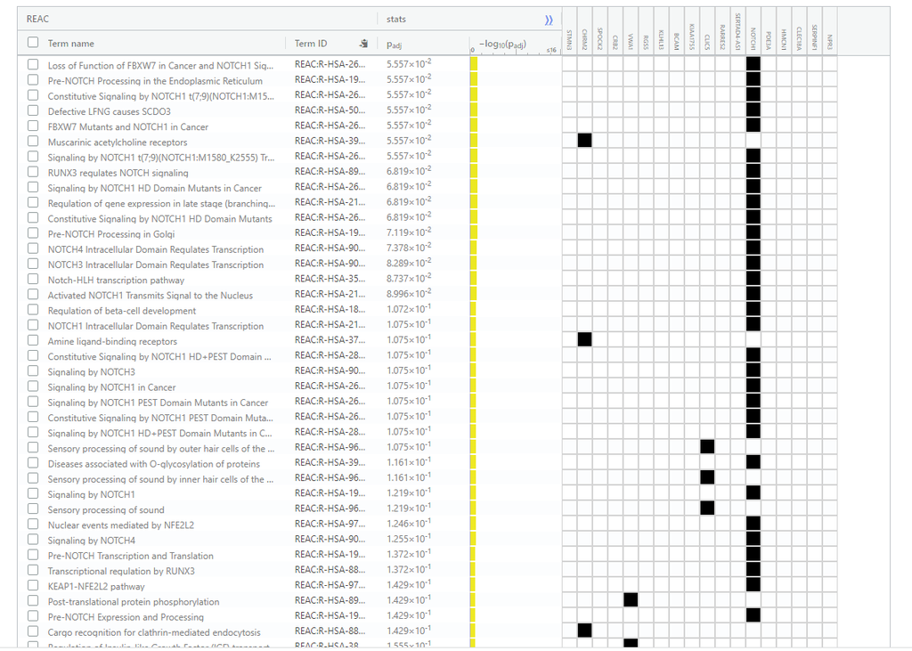

*Figure 5. Up-regulated genes over-representation analysis results from Reactome, term size = 200.*

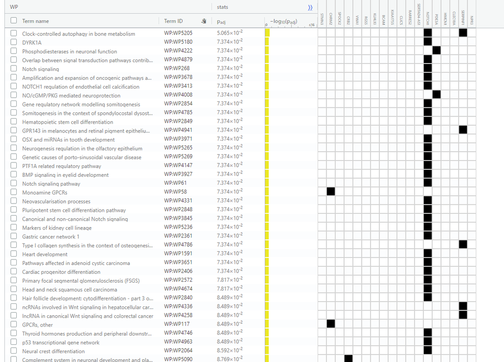

*Figure 6. Up-regulated genes over-representation analysis results from WikiPathways, term size = 200.*

### results only using the downregulated genes:

The top-hit term for GO:BP is negative regulation of viral process, Interferon alpha/beta signaling for reactome, and Type I interferon induction and signaling during SARS-CoV-2 infection.

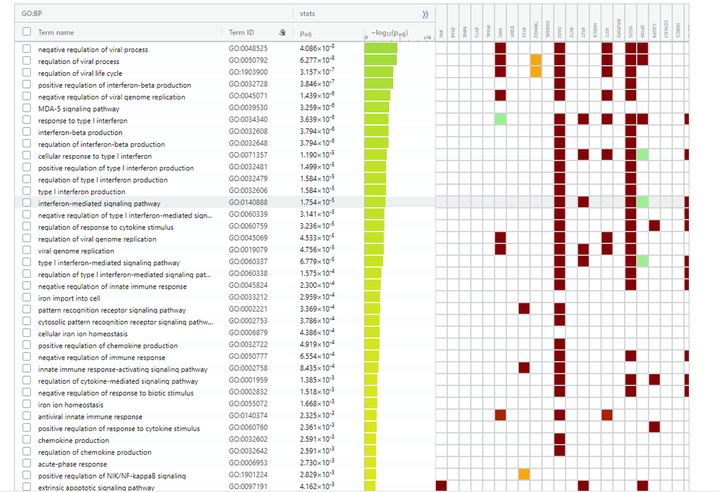

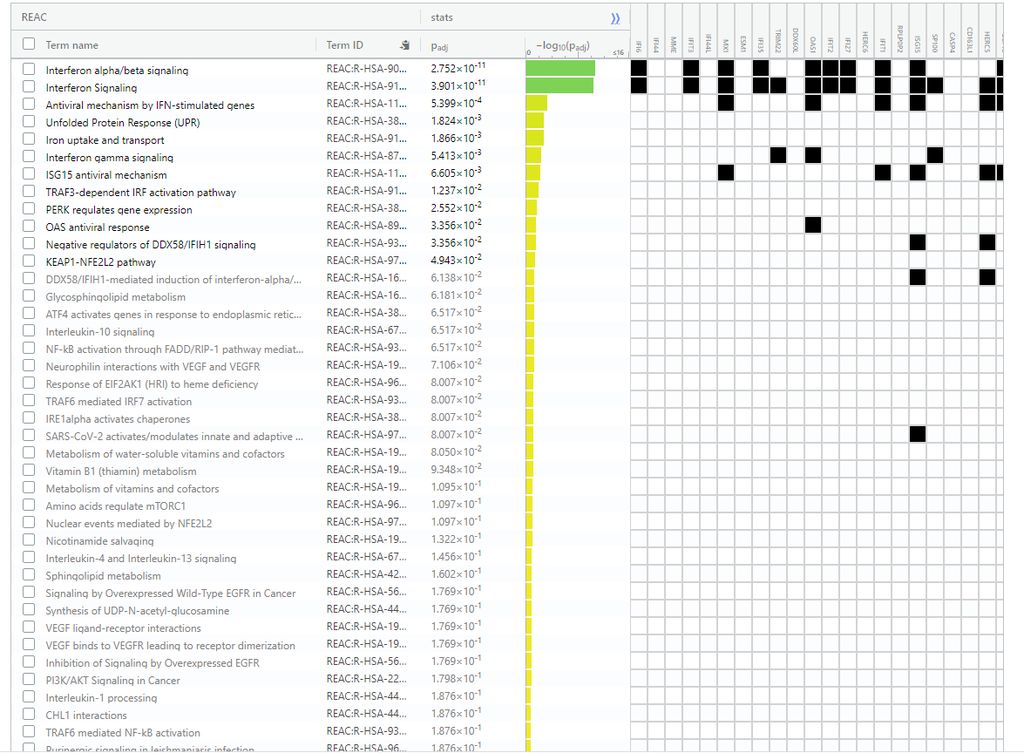

*Figure 8. down-regulated genes over-representation analysis results from Reactome, term size = 200.*

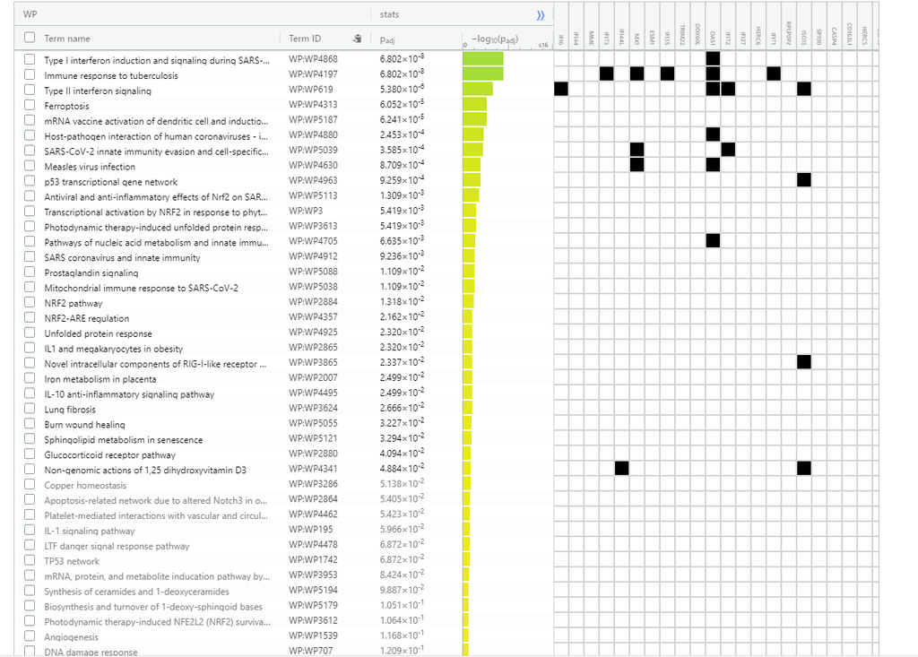

*Figure 9. down-regulated genes over-representation analysis results from WikiPathways, term size = 200.*

# Interpretation

**Do the over-representation results support conclusions or mechanism discussed in the original paper?**

**Can you find evidence, i.e. publications, to support some of the results that you see. How does this evidence support your results.**

Yes, in our results it show that IFI44 as being the second strongest differencial expressed gene. IFI44 is a member of the ISG class, which aggregates to form microtubular structures within the cytoskeleton, facilitating intracellular transport of secretory vesicles, and regulates cell division through mitosis and meiosis. In paper [Type III interferons produced by human placental trophoblasts confer protection against Zika virus infection](http://dx.doi.org/10.1016/j.chom.2016.03.008)(Bayer et al. 2016), it identified that IFI44 is expressed in the trophoblast and may be a part of the innate immune response of pregnancy.

# References

Bayer, Avraham, Nicholas J Lennemann, Yingshi Ouyang, John C Bramley, Stefanie Morosky, Ernesto Torres De Azeved Marques, Sara Cherry, Yoel Sadovsky, and Carolyn B Coyne. 2016. “Type III Interferons Produced by Human Placental Trophoblasts Confer Protection Against Zika Virus Infection.” *Cell Host & Microbe* 19 (5): 705–12.

Benjamini, Yoav, and Yosef Hochberg. 1995. “Controlling the False Discovery Rate: A Practical and Powerful Approach to Multiple Testing.” *Journal of the Royal Statistical Society: Series B (Methodological)* 57 (1): 289–300.

Gu, Zuguang, Roland Eils, and Matthias Schlesner. 2016. “Complex Heatmaps Reveal Patterns and Correlations in Multidimensional Genomic Data.” *Bioinformatics* 32 (18): 2847–49.

Gu, Zuguang, Lei Gu, Roland Eils, Matthias Schlesner, and Benedikt Brors. 2014. “Circlize Implements and Enhances Circular Visualization in r.” *Bioinformatics* 30 (19): 2811–12.

Kolberg, Liis, Uku Raudvere, Ivan Kuzmin, Jaak Vilo, and Hedi Peterson. 2020. “Gprofiler2–an r Package for Gene List Functional Enrichment Analysis and Namespace Conversion Toolset g: Profiler.” *F1000Research* 9.

Morgan, Martin. 2022. *BiocManager: Access the Bioconductor Project Package Repository*. https://CRAN.R-project.org/package=BiocManager.

Müller, Kirill, and Hadley Wickham. 2022. *Tibble: Simple Data Frames*.

Pinney, Sara E, Apoorva Joshi, Victoria Yin, So Won Min, Cetewayo Rashid, David E Condon, and Paul Zhipang Wang. 2020. “Exposure to Gestational Diabetes Enriches Immune-Related Pathways in the Transcriptome and Methylome of Human Amniocytes.” *The Journal of Clinical Endocrinology & Metabolism* 105 (10): 3250–64.

R Core Team. 2022. *R: A Language and Environment for Statistical Computing*. Vienna, Austria: R Foundation for Statistical Computing. https://www.R-project.org/.

Ritchie, Matthew E, Belinda Phipson, DI Wu, Yifang Hu, Charity W Law, Wei Shi, and Gordon K Smyth. 2015. “Limma Powers Differential Expression Analyses for RNA-Sequencing and Microarray Studies.” *Nucleic Acids Research* 43 (7): e47–47.

Robinson, Mark D, Davis J McCarthy, and Gordon K Smyth. 2010. “edgeR: A Bioconductor Package for Differential Expression Analysis of Digital Gene Expression Data.” *Bioinformatics* 26 (1): 139–40.

Wickham, Hadley. 2010. “Stringr: Modern, Consistent String Processing.” *R J.* 2 (2): 38.

———. 2016. *Ggplot2: Elegant Graphics for Data Analysis*. Springer-Verlag New York. https://ggplot2.tidyverse.org.

Wickham, Hadley, Romain François, Lionel Henry, and Kirill Müller. 2022. *Dplyr: A Grammar of Data Manipulation*. https://CRAN.R-project.org/package=dplyr.

Wickham, Hadley, and Maintainer Hadley Wickham. 2017. “Package ‘Tidyr’.” *Easily Tidy Data with’spread’and’gather ()’Functions*.

Xie, Y. 2016. “Knitr: A General-Purpose Package for Dynamic Report Generation in r (r Package Version 1.15. 1)[computer Software].” *Zugriff Am* 7 (10): 2016.